# 5 R Objects

> first things first : Upload libraries

**It’s a good practice to start a quarto document (or a R file) by loading the libraries we will use**. Those libraries can be related to the ETL, the Data Visualization (Charts, Tables), some special calculations, shiny web apps, etc…

Here, we will start practicing on the ETL, and will load very often the R package `tidyverse`.

The `tidyverse` is a collection of inter-operable R packages for data science that share a common design philosophy, grammar, and data structures. This package is one of the reasons why **R is so popular for data manipulation capabilities**.

Among those packages, we have :

- `dplyr` : Data manipulation (wrangling).
- `tidyr` : Data tidying of CSV or TSV files.
- `stringr` : String manipulation, provides a cohesive set of functions for working with character data.
- `forcats` : Factor manipulation.
- `lubridate` : simplifies working with dates and times.

**Everything is an object:** In R, virtually everything, including functions, vectors, and lists, is an object. **An object’s class defines its structure**.

In this part, we are going to look at the main objects that we will use in R :

- **vectors.**
- **data frames.**

And the different *classes* of variables which composed those objects, with a particular focus on :

- factor.
- list.

We will learn :

- how to **create data frames,** and to **upload** **data** (from a csv or an excel file) and **write** them (into a csv or an excel file)
- the very basic syntax to :
  - create an object.
  - access a particular variable of a data frame.

We will also introduce some first *functions*, such as :

- `data.frame()` : to create a data frame.
- `as.Date()` : to create a date.
- `class()` : to check the class of an object.
- `str()` : to check the content (the structure) of an object.

**A function is a word**, which performs an operation. It is displayed as the **name of the function followed by 2 parentheses ()**. The function is applied to an object, or some variables of it, which are placed between the 2 parentheses.

# 6 Different data structures & classes

> different data structures

R handles several types of *Data Structures*, especially :

- vector.
- data frame.
- matrix.
- array.
- list.

Through this book, we will use mainly vectors, data frames, and lists.

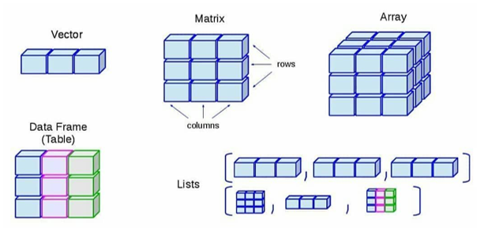

Figure 21 : different existing data structures

> different classes

A **class** characterizes the **format of the values which are contained inside a data structure**, or the data structure itself.

Most common ones are:

- numeric.
- integer.
- character.
- factor.
- date.
- logical.
- list.

And of course :

- data frame, or a *tibble*, which is a modern, enhanced version of R’s traditional data.frame.

We will look at them gradually more in details in the coming parts.

# 7 Create a vector

It’s **the most basic object, and a key element, in the R ecosystem**.

It’s also the component of other objects, such as data frames or lists.

To create a vector, we just need to type the syntax below :

- start with the letter “**c**” and add 2 parentheses : **c()** .
- then between parentheses, write some elements, **separated by a comma** .

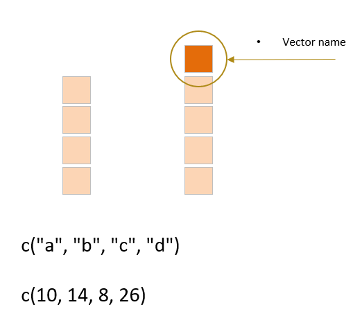

Figure 22 : a vector

Let’s create our first vector, composed of characters :

```r
c("a", "b", "c", "d")
```

```
[1] "a" "b" "c" "d"
```

**Note :** if we want to handle some **characters**, we need to put them *between 2 quotes ““* .

For example :

- 100 will be captured as a numeric value.
- whereas “100” will be captured as a character.

Here is a vector with numeric values :

```r
c(10, 14, 8, 26)
```

```
[1] 10 14  8 26
```

We have created 2 vectors, but we can’t see them as existing objects : they don’t appear in our environment, in the top right panel of our IDE.

In order to use them later on, *we need to affect an object, through a name*, to those vectors.

# 8 Define an object

To **affect an object name to a vector**, we simply use the syntax below :

First we **define a name for our object**, and then **using an arrow, written “<-”** we affect an object, here a vector, to it.

This object can also be a data frame or a list, as we will see later on.

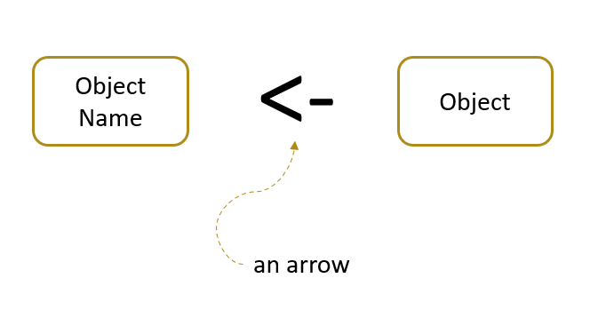

Figure 23 : give an name to an object using an arrow

Let’s practice :

We create an object call “people”.

```r
# create vector
people <- c("Seb", "Max", "Nico", "Greg")
```

Note that **this object now appears on the top right of your IDE, in your environment**. It means that it exists (in your environment) : **you can access it and you can use it later on**.

We get an overview of it, and can notice some useful information :

- its class is a character : it’s written “chr” at the beginning.
- it contains 1 to 4 elements : it’s written between bracket [1:4].
- a snapshot of the first elements is displayed : “Seb” “Max” “Nico” “Greg”.

[figure not shown]

Figure 24 : overview of our first object

You also can type in a chunk of a quarto document the name of the object, and it will be displayed below the chunk :

```r
# display
people
```

```
[1] "Seb"  "Max"  "Nico" "Greg"
```

Let’s look at the class of this vector :

```r
class(people)
```

```
[1] "character"
```

Let’s have another example, this time using some numerical values :

```r
# create vector
age <- c(10, 14, 8, 26)

# display
age
```

```
[1] 10 14  8 26
```

# 9 A data frame

## 9.1 Create data frame

A `data frame` is like a table, composed of vectors.

- the vectors are the columns, that we will call more specifically **variables**.
- **the vectors’ names are the variables’ names**.

It’s what we (very) often use in excel.

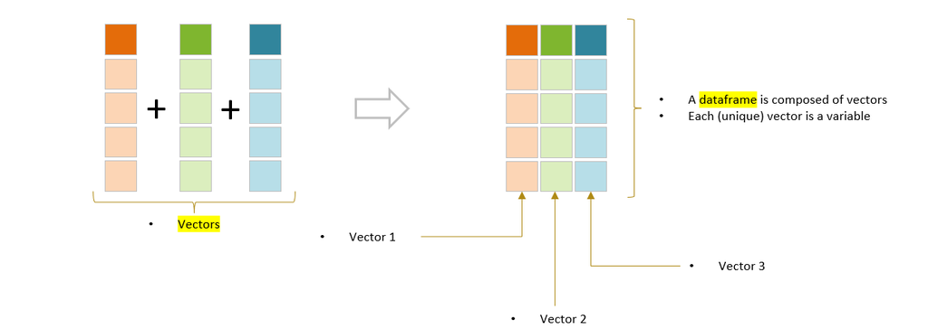

Figure 25 : structure of a data frame

So **we can create a data frame by combining some vectors**.

Here is one way, creating the vectors first and them combining them into a data frame :

- we create first 2 vectors of 4 elements each.
- we assemble them into a data frame with the function `data.frame()`*.*

```r
# create vectors
people <- c("Tom", "Max", "Nico", "Greg")
age <- c(10, 14, 8, 26)

# combine them into a dataframe, using the data.frame() function
mydataframe <- data.frame(
  people,
  age
  )

# display
mydataframe
```

```
  people age
1    Tom  10
2    Max  14
3   Nico   8
4   Greg  26
```

We can use the function `glimpse()` to **display an overview of the data frame and also get some information about the class of each variable**, next to its name :

```r
glimpse(mydataframe)
```

```
Rows: 4
Columns: 2
$ people <chr> "Tom", "Max", "Nico", "Greg"
$ age    <dbl> 10, 14, 8, 26
```

- next to people : “chr” stands for “character”.
- next to age : “dbl” stands for “double”, i.e. a numerical value.

Here is another way to create a data frame, creating the variables straight into a `data.frame()` function :

```r
# create straight away the dataframe
mydataframe <- data.frame(
  people = c("Tom", "Max", "Nico", "Greg"),
  age = c(10, 14, 8, 26)
  )


# display
mydataframe
```

```
  people age
1    Tom  10
2    Max  14
3   Nico   8
4   Greg  26
```

Let’s look at the class of the object “mydataframe” : it’s a data.frame

```r
class(mydataframe)
```

```
[1] "data.frame"
```

## 9.2 Display data frame

Let’s explore a bit the RStudio IDE.

### 9.2.1 A complete data frame

We can click on the name of object on the top right of the RStudio IDE, in the Environment tab, and the object will appear in a new window.

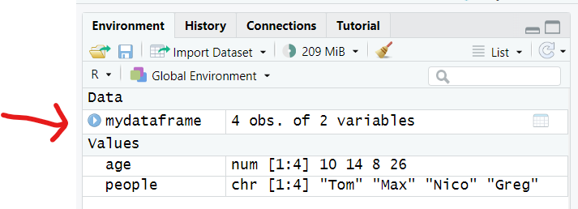

Figure 26 : display object in a new window

It now appears in a new tab or window in the top left panel of RStudio. You can click on it to display it.

You can :

- click on the variables’ names to sort the data.
- click on the *Filter button* to display some “search” boxes below the variables’ names and filter some data.

We also have a few info about the data frame on its bottom left :

- number of entries (i.e. the rows) which are displayed.
- number of columns of the data frame.

[figure not shown]

Figure 27 : view of the object “mydataframe”

### 9.2.2 An overview

In the Environment tab, you can click on the little blue arrow on the left (of the object) to see the composition of the data frame :

- first variable is a vector of characters.
- second variable is a vector of numerical values.

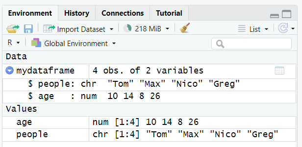

Figure 28 : overview of the object “mydataframe”

## 9.3 Access variable of a data frame

We now have a data frame, and we will be able to perform some manipulations and calculations on it later on.

We can select a variable of a data frame using the syntax `object_name$variable_name` .

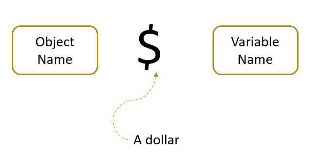

Figure 29 : select a variable of a data frame

Using our previous data frame, let’s select the variable “people” :

```r
# select the variable "people"
mydataframe$people
```

```
[1] "Tom"  "Max"  "Nico" "Greg"
```

# 10 A List

## 10.1 Create a list

It might be at the beginning a bit challenging to figure out what is a list.

*We often describe a list as a train*.

A list is group of different elements, and those elements can be of different types (i.e class). Each element has a location within the list, like inside the cars of a train.

For example, we can have inside a list :

- a vector.
- but also a vector and a data frame.
- or several lists.
- …

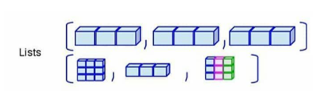

Figure 30 : example of composition of lists

To illustrate it, let’s create a list composed of 2 elements :

- the vector called “people”.
- the data.frame called “mydataframe”.

We will use the function `list()` to generate this object.

```r
# create list
mylist <- list(people, mydataframe)

# display list
mylist
```

```
[[1]]
[1] "Tom"  "Max"  "Nico" "Greg"

[[2]]
  people age
1    Tom  10
2    Max  14
3   Nico   8
4   Greg  26
```

We can see that the object “mylist” appears here with 2 elements. **Each element is located at a specific position**.

To access one element located inside a specific position, we simply need to write : the name of the object (i.e. the list) and between 2 square brackets the location.

For example, to get the data frame which is located in the second position, we will write :

```r
mylist[[2]]
```

```
  people age
1    Tom  10
2    Max  14
3   Nico   8
4   Greg  26
```

or to get the vector:

```r
mylist[[1]]
```

```
[1] "Tom"  "Max"  "Nico" "Greg"
```

## 10.2 Display a list

The object “mylist” now appears on the top right of the RStudio IDE.

You can click on the little arrow on the left to see its composition :

- first location contains a vector of characters.
- second location contains a data frame.

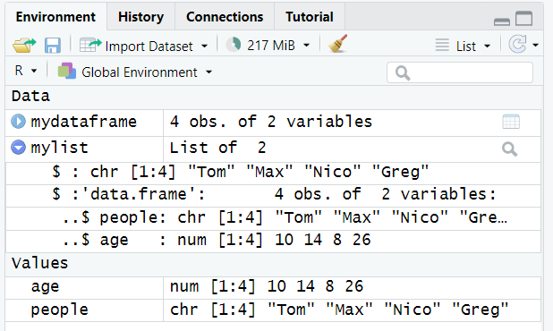

Figure 31 : overview of the object “mylist”

## 10.3 More about lists

The list class is a very flexible class, and is very useful to perform some analysis or to create some particular displays in some tables, such as **sparklines**. We will practice in the next chapters.

As we saw before in the section data structures, we can put anything inside a list, such as numbers:

```r
list1 <- list(3, 2)

list1
```

```
[[1]]
[1] 3

[[2]]
[1] 2
```

Or other vectors constructed with c():

```r
list2 <- list(c(1, 2), c(3, 4))

list2
```

```
[[1]]
[1] 1 2

[[2]]
[1] 3 4
```

You can also put objects of different classes in the same list:

```r
list3 <- list(3, c(1, 2), "lists are amazing!")

list3
```

```
[[1]]
[1] 3

[[2]]
[1] 1 2

[[3]]
[1] "lists are amazing!"
```

And of course create list of lists:

```r
my_lists <- list(list1, list2, list3)

my_lists
```

```
[[1]]
[[1]][[1]]
[1] 3

[[1]][[2]]
[1] 2


[[2]]
[[2]][[1]]
[1] 1 2

[[2]][[2]]
[1] 3 4


[[3]]
[[3]][[1]]
[1] 3

[[3]][[2]]
[1] 1 2

[[3]][[3]]
[1] "lists are amazing!"
```

To check the contents of a list, you can use the structure function `str()` :

```r
str(my_lists)
```

```
List of 3
 $ :List of 2
  ..$ : num 3
  ..$ : num 2
 $ :List of 2
  ..$ : num [1:2] 1 2
  ..$ : num [1:2] 3 4
 $ :List of 3
  ..$ : num 3
  ..$ : num [1:2] 1 2
  ..$ : chr "lists are amazing!"
```

And you can use the function `class()` to check the class of the object :

```r
class(my_lists)
```

```
[1] "list"
```

# 11 More about Classes

We already saw a few types of classes so far : characters, numerical values, data frames and lists.

Numerical values can be :

- integer.
- double (i.e a numerical values which is not an integer).

There are also 3 very useful classes :

- date.
- factor.
- logical.

Remember that to check the class of an object, we can use the function `class()`.

## 11.1 Date

### 11.1.1 Create a date

We will see through this book that R allows us to handle very easily dates coming in very different formats, especially using the package `lubridate`.

For the time being, let’s notice how is identified the class of a date object.

First, let’s create a date, as a character :

```r
# create date, in the format MM/DD/YYY
mydate <- "05/01/2025"

# display
mydate
```

```
[1] "05/01/2025"
```

Now, let’s convert it into a proper date, using the function `as.Date()`:

```r
# convert as a date
mydate <- as.Date(mydate, format = '%m/%d/%Y')

# display
mydate
```

```
[1] "2025-05-01"
```

The display is already different from previously, and “mydate” now appears in a standardized format : YYYY-MM-DD

We can check the class :

```r
class(mydate)
```

```
[1] "Date"
```

### 11.1.2 More about dates

**Numeric weekday**

- Weekday as a decimal number (1-7, Monday is 1): %u
- Weekday as decimal number (0-6, Sunday is 0): %w
- Interestingly, there is no format for the case Sunday is counted as day 1 of the week.

In the table below are the main dates conversions that we will use through this book.

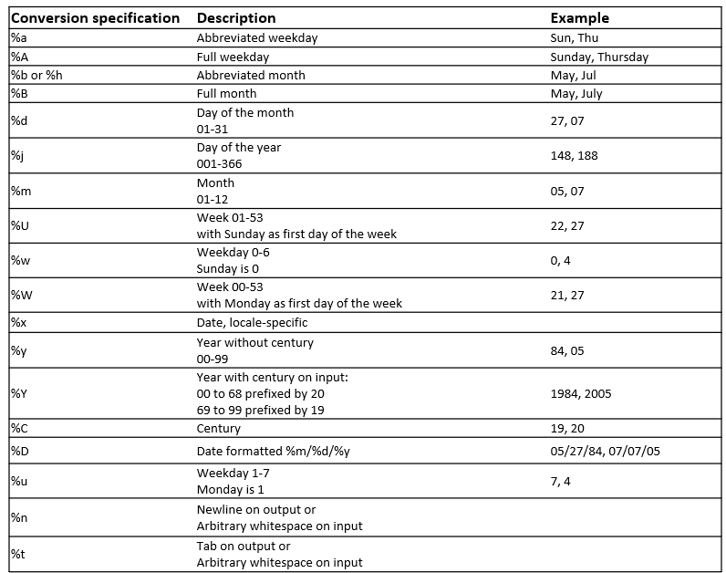

Figure 32 : different date formats

## 11.2 A Factor

Here comes a super useful type of class.

To illustrate it, imagine that we are working for a company who is using a Fiscal Calendar, with the month of October as first month of this fiscal year.

We can create an object (data frame), called fiscal_calendar_data as below :

```r
# create calendar
fiscal_calendar_data <- data.frame(

  calendar_month_abb = c("Oct", "Nov", "Dec", "Jan", "Feb", "Mar",
                         "Apr", "May", "Jun", "Jul", "Aug", "Sep"),

  fiscal_month = c(1,2,3,4,5,6,7,8,9,10,11,12)
  )

# display
fiscal_calendar_data
```

```
   calendar_month_abb fiscal_month
1                 Oct            1
2                 Nov            2
3                 Dec            3
4                 Jan            4
5                 Feb            5
6                 Mar            6
7                 Apr            7
8                 May            8
9                 Jun            9
10                Jul           10
11                Aug           11
12                Sep           12
```

We notice that the variable “calendar_month_abb” is a character.

Let’s open it, by clicking on the object fiscal_calendar_data in our Environment (top right). Now, we can click on the variable calendar_month_abb : it allows us to sort the different elements.

We notice that the different elements are sorted according to an alphabetical order (from start to end or the opposite). It’s because the class is a character.

We can change this, by modifying the class of the variable calendar_month_abb, into a *factor*.

We will define *levels*, to indicate a new order for this variable

```r
# create a Factor for the variable calendar_month_abb
# setting the beginning to October, to reflect the beginning of a Fiscal Year
fiscal_calendar_data$calendar_month_abb <- factor(
  fiscal_calendar_data$calendar_month_abb,

    levels = c("Oct", "Nov", "Dec", "Jan","Feb","Mar",
               "Apr","May","Jun","Jul","Aug","Sep")
  )
```

Now let’s look again at our object fiscal_calendar_data :

```r
# display
fiscal_calendar_data
```

```
   calendar_month_abb fiscal_month
1                 Oct            1
2                 Nov            2
3                 Dec            3
4                 Jan            4
5                 Feb            5
6                 Mar            6
7                 Apr            7
8                 May            8
9                 Jun            9
10                Jul           10
11                Aug           11
12                Sep           12
```

The variable calendar_month_abb has a class “**fctr**” which stands for *factor*.

When we sort it, it starts from October, and ends in September.

> A factor is a bit like having an attribute (here called a level), on top of a value (here a month, in character).

This will be for example pretty convenient to display some charts (continuing the example of this dataset).

## 11.3 Logical class

This class is the result of logical comparisons, for example, if you type:

```r
# create a test
4 > 3
```

```
[1] TRUE
```

R returns TRUE, which is an object of class logical:

```r
# affect an object called "k" to this test
k <- 4 > 3

# check the class of the object k
class(k)
```

```
[1] "logical"
```

In other programming languages, logicals are often called bools.

A logical variable can only have two values, either TRUE or FALSE.

You can test the truthfulness of a variable with the function `isTRUE()` :

```r
k <- 4 > 3
isTRUE(k)
```

```
[1] TRUE
```

How can you test if a variable is false?

There is not a *isFALSE()* function (at least not without having to load a package containing this function), but there is way to do it, adding a “!” before the the function `isTRUE()`:

```r
k <- 4 > 3
!isTRUE(k)
```

```
[1] FALSE
```

The **! operator indicates negation**, so the above expression could be translated as is k not TRUE?